# Introduction to R language

Fifth Session

Grado Ciencia de Datos

# Generación de Guión de Ejercicios

Compila este documento en formato HTML y genera el documento de los ejercicios (todavía sin completar) de la sesión de Introducción al Lenguaje R.

# Control Structures

## Flow control functions

### `if-else`

```r
if(<condition>) {
    ## do something
} else {
    ## do something else
}
```

```r
x<-F
if (x==TRUE) {
  print("X is TRUE")
} else {
  print("X is FALSE")
}
```

```
## [1] "X is FALSE"
```

**Ejercicio** Utiliza la versión vectorizada de if-else `ifelse(cond, expr1, expr2)` para tranformar el vector `x` en el vector `y` de tal manera que los impares se tranformen en el valor 0 y los pares se transformen en la mitad.

```r
x<-c(3L, 16L, 11L, 9L, 16L, 7L, 17L, 14L, 17L, 15L, 20L, 14L, 14L,
4L, 1L, 8L, 14L, 2L, 14L, 12L)
```

### `switch`

- the switch statement (not vectorised)
- expr.string evaluates to a char string
- cases not enclosed in quotes.

```r
switch( expr.string,
  case1 = expr1,
  case2 = expr2,
  default = expr3 # default optional
)
```

```r
x<-"F"
switch(x,
  T = "X is TRUE",
  F = "X is FALSE"
)
```

```
## [1] "X is FALSE"
```

## Control structure

### `for`

```r
for(<condition>) {
    ## do something
}
```

```r
join<-character() # empty character vector
vector<-c("A", "B", "C", "D", "E") # character vector
for(letter in vector) { #loop through letter in character vector
    join<-c(letter,join)
    print(join)
}
```

```
## [1] "A"
## [1] "B" "A"
## [1] "C" "B" "A"
## [1] "D" "C" "B" "A"
## [1] "E" "D" "C" "B" "A"
```

**Ejercicio** Aprovechando la función `seq_along(vector)` que crea una secuencia de valores 1:length(vector) reescribe el código del ejercicio anterior.

### `while`

```r
while(<condition>) {
   ## do something
}
```

```r
x<-sample.int(10,1) #random number [1-10]
x
```

```
## [1] 7
```

```r
while(x>0) { #while x is positive
   x<- x-1
  print(x)
}
```

```
## [1] 6
## [1] 5
## [1] 4
## [1] 3
## [1] 2
## [1] 1
## [1] 0
```

**Ejercicio** Realiza un buble con `while` para calcular la estimación de la raíz cuadrada $x$ de un número $S=150$ siguiendo la siguiente relación iterativa (método Babilónico):

$x \leftarrow \frac{1}{2}(x+\frac{S}{x})$

sidendo $x=100$ (por ejemplo) la estimación inicial de $\sqrt{S}.$ Detén las iteraciones cuando el error sea inferior a 0.001 (Pista: $abs(\sqrt{S}-x)<0.001$)

```r
S<-150 #valor del que queremos calcular la raiz
x<-100 #valor inicial estimación de la raiz

x<-1/2*(x+S/x) #valor estimado con 1 iteración (falta el bucle)
cat("Valor estimado sqrt(S):",x,"\n")
```

```
## Valor estimado sqrt(S): 50.75
```

# Functions

## Returning an object

By default the value of the last evaluation which is returned from the function.

```r
f<- function() {
  x<-1
  z<-2 #last evaluation
}
output<-f()
output #z value
```

```
## [1] 2
```

## Argument matching

Argument matching order: exact $\rightarrow$ partial $\rightarrow$ positional

```r
f<-function(value) {
  value^2 #last evaluation is returned
}
f(value=2) #exact matching
```

```
## [1] 4
```

```r
f(v=2)#partial matching
```

```
## [1] 4
```

```r
f(2)#positional matching
```

```
## [1] 4
```

## Lazy Evaluation

R will evaluate as needed, so everything executes until an error occurs.

```r
f <- function (a, b) {a^2}
f(a=5,b=NULL)
```

```
## [1] 25
```

```r
f(5) # Lazy Evaluation
```

```
## [1] 25
```

##Default and missing arguments

Function arguments in R can have default values.

```r
f <- function(a = 1, b = 2) {
  c(a, b)
}
f()
```

```
## [1] 1 2
```

```r
f(3,4)
```

```
## [1] 3 4
```

```r
f(7)
```

```
## [1] 7 2
```

```r
f(,9)
```

```
## [1] 1 9
```

## … arguments

The … argument means that you can add other arguments which will be passed to functions inside the function.

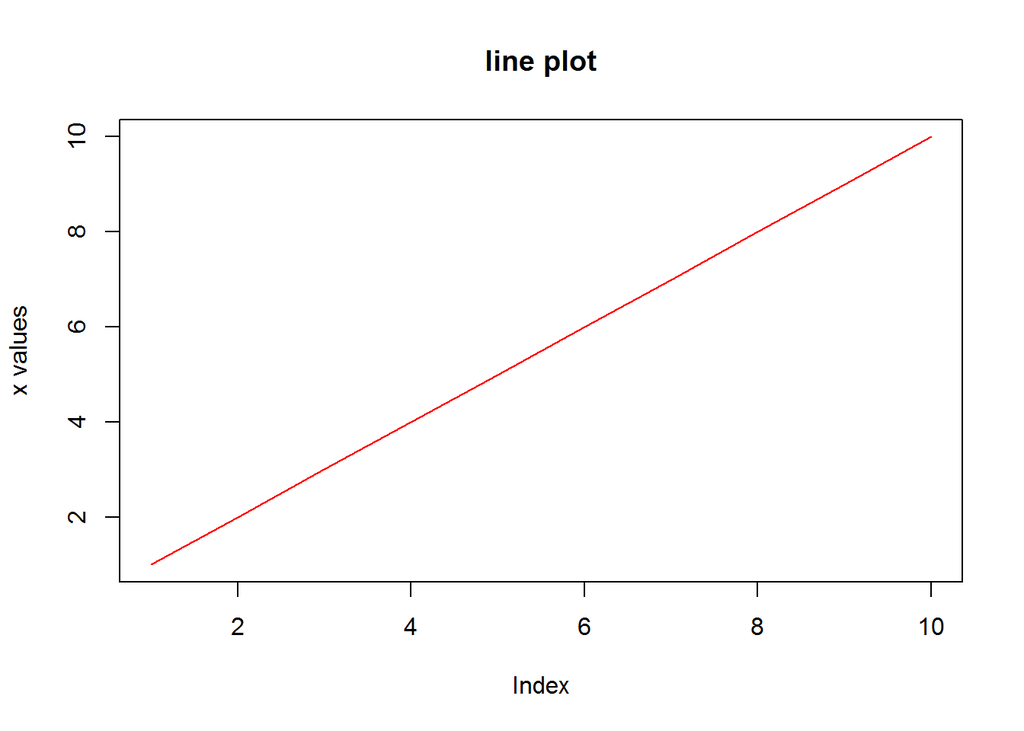

```r
my.plot <- function(x,...){
    plot(x, type = "l", ...)
}
x<-1:10
my.plot(x, main = "line plot", col= "red",ylab="x values")
```

# Functions DataScience

## Statistic Function

### mean

```r
x<-seq(1,5,0.1);y<-exp(x);
mean(y)
```

```
## [1] 37.40801
```

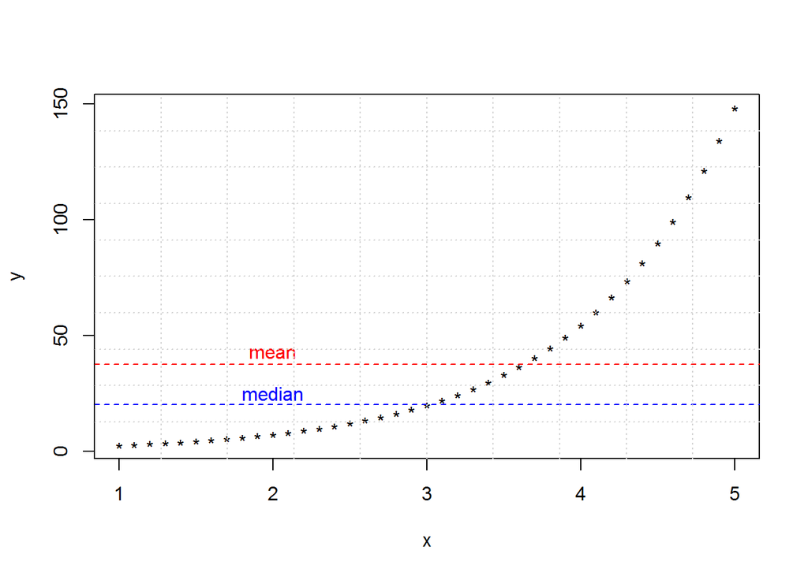

```r
plot(x,y,pch="*")
abline(h=mean(y),col="red",lty=2)
text(2,mean(y)+5,"mean",col="red")
abline(h=median(y),col="blue",lty=2)
text(2,median(y)+5,"median",col="blue")
grid(10,10)
```

**Ejercicio** ¿por qué no funciona la función que calcula el valor medio? ¿qué argumento es necesario modificar?

```r
x<-c(10, NA, 13, 35, -12, 0, 1, 17, 9999, 19, 21, NA)
mean(x)
```

```
## [1] NA
```

### sd

**Ejercicio** El intervalo de confianza del valor valor medio al 95% de confianza se se define: $\mu\pm1.96\frac{\sigma}{\sqrt{N}}$  
siendo $\mu$ el valor medio, $\sigma$ la desviación estandar y $N$ el número de valores.

```r
x<-c(10, NA, 13, 35, -12, 0, 1, 17, 15, 19, 21, NA)

#solution
mean(x,na.rm=TRUE)
```

```
## [1] 11.9
```

```r
mean(x,na.rm=TRUE)-1.96*sd(x,na.rm=TRUE)/sqrt(length(x[!is.na(x)]))
```

```
## [1] 3.795243
```

```r
mean(x,na.rm=TRUE)+1.96*sd(x,na.rm=TRUE)/sqrt(length(x[!is.na(x)]))
```

```
## [1] 20.00476
```

**Ejercicio** La función `fivenum` proporciona las 5 medidas (min, lower-hinge, median, upper-hinge, max )propuestas por uno de los padres del análsis de datos John W. Tukey. Las medidas son muy parecidas a los valores proporcionados por la función `summary`. Comprueba que cuando el número de medidas es impar, el resultado es el mismo y cuando el número de muestras de par no.

```r
#ODD Set of Numbers in the sample
x.odd<-c(33, 34, 55, 57, 60, 61, 61, 2, 3, 5, 6, 7, 8, 12, 15, 18, 20, 27, 28, 29, 70)
#EVEN Set of Numbers in the sample (multiple of 4)
x.even<-c(33, 34, 55, 57, 60, 61, 61, 3, 5, 6, 7, 8, 12, 15, 18, 20, 27, 28, 29, 70)
```

# Avoid Loops

## lapply & sapply

`lapply(X, FUN, ...)` returns a list of the same length as X, each element of which is the result of applying FUN to the corresponding element of X.

`sapply(X, FUN, ...)` user-friendly version and wrapper of lapply by default returning a vector, matrix or, if simplify = “array”, an array if appropriate, by applying simplify2array().

```r
x.list<-list(a=c(10L, 9L, 8L, 7L, 6L, 5L, 4L, 3L), b=c(10L, 9L, 8L, 7L, 6L,
5L, 4L), c=c(10L, 9L, 8L, 7L, 6L, 5L, 4L, 3L, 2L), d=c(10L, 9L, 8L,
7L, 6L, 5L, 4L, 3L, 2L, 1L), e=c(10L, 9L, 8L, 7L, 6L, 5L))
str(x.list)
```

```
## List of 5
##  $ a: int [1:8] 10 9 8 7 6 5 4 3
##  $ b: int [1:7] 10 9 8 7 6 5 4
##  $ c: int [1:9] 10 9 8 7 6 5 4 3 2
##  $ d: int [1:10] 10 9 8 7 6 5 4 3 2 1
##  $ e: int [1:6] 10 9 8 7 6 5
```

```r
r.apply<-lapply(x.list,length) #returns a list
str(r.apply)
```

```
## List of 5
##  $ a: int 8
##  $ b: int 7
##  $ c: int 9
##  $ d: int 10
##  $ e: int 6
```

```r
s.apply<-sapply(x.list,length) #returns a named vector
str(s.apply)
```

```
##  Named int [1:5] 8 7 9 10 6
##  - attr(*, "names")= chr [1:5] "a" "b" "c" "d" ...
```

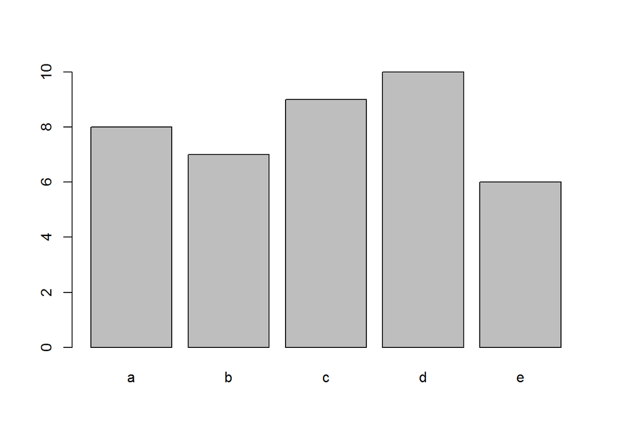

```r
barplot(s.apply)
```

**Ejercicio** Determina el rango intercuartil de cada elemento de la lista. Determina también el coeficiente de varianza (sd/mean) utilizando una función `cv` que lo calcule.

```r
x.list<-list(a=c(10L, 9L, 8L, 7L, 6L, 5L, 4L, 3L), b=c(10L, 9L, 8L, 7L, 6L,
5L, 4L), c=c(10L, 9L, 8L, 7L, 6L, 5L, 4L, 3L, 2L), d=c(10L, 9L, 8L,
7L, 6L, 5L, 4L, 3L, 2L, 1L), e=c(10L, 9L, 8L, 7L, 6L, 5L))
```

## tapply

`tapply(X, INDEX, FUN = NULL, ..., simplify = TRUE)` Apply a function to each cell of a ragged array, that is to each (non-empty) group of values given by a unique combination of the levels of certain factors.

```r
load(file="tapplyExercise.RData") #load df
median(df[df$f=="X","v"]) #median of v with f=X
```

```
## [1] 7
```

```r
median(df[df$f=="Y","v"]) #median of v with f=Y
```

```
## [1] 5
```

```r
tapply(df$v, df$f, median) #median of v grouped by f
```

```
## X Y
## 7 5
```

**Ejercicio** Determina el número de roturas (breaks) sufre cada tipo de lana (wool) dependiendo de la tensión aplicada (tension). Reliza un gráfico de mosaico.

```r
#help(data("warpbreaks"))
data("warpbreaks") #load data warpbreaka
str(warpbreaks)
```

```
## 'data.frame':    54 obs. of  3 variables:
##  $ breaks : num  26 30 54 25 70 52 51 26 67 18 ...
##  $ wool   : Factor w/ 2 levels "A","B": 1 1 1 1 1 1 1 1 1 1 ...
##  $ tension: Factor w/ 3 levels "L","M","H": 1 1 1 1 1 1 1 1 1 2 ...
```

## apply

`apply(X, MARGIN, FUN, ...)` Returns a vector or array or list of values obtained by applying a function to margins of an array or matrix.

- Object: m, t, df, a (has 2+ dimensions)
- Returns: v, l, m (depends on input & fn)
- *margin=2* indicates columns
- *margin=1* indicates rows

```r
m<-matrix(1:10,nrow=10,ncol=3)
m
```

```
##       [,1] [,2] [,3]
##  [1,]    1    1    1
##  [2,]    2    2    2
##  [3,]    3    3    3
##  [4,]    4    4    4
##  [5,]    5    5    5
##  [6,]    6    6    6
##  [7,]    7    7    7
##  [8,]    8    8    8
##  [9,]    9    9    9
## [10,]   10   10   10
```

```r
apply(m, 2, sum) #column.sum, margin=2 indicates columns
```

```
## [1] 55 55 55
```

```r
apply(m, 1, sum) #row.sum, margin=1 indicates rows
```

```
##  [1]  3  6  9 12 15 18 21 24 27 30
```

**Ejercicio** Determina cuántas veces aparece cade letra en cada columna.

```r
     [,1] [,2] [,3]
 [1,] "A"  "F"  "B"
 [2,] "B"  "F"  "B"
 [3,] "E"  "B"  "B"
 [4,] "B"  "F"  "D"
 [5,] "C"  "E"  "C"
 [6,] "E"  "D"  "A"
 [7,] "F"  "D"  "A"
 [8,] "E"  "F"  "A"
 [9,] "E"  "A"  "D"
[10,] "C"  "F"  "C"
```

```r
x<-c("A", "B", "E", "B", "C", "E", "F", "E", "E", "C", "F", "F",
"B", "F", "E", "D", "D", "F", "A", "F", "B", "B", "B", "D", "C",
"A", "A", "A", "D", "C")
m<-matrix(x,nrow=10,ncol=3)
```

# Generación de Guión de Ejercicios Completos

Compila este documento en formato HTML y genera el documento de los ejercicios (¡ahora completados!) de la sesión de Introducción al Lenguaje R.